# Assignment 7 Sanket

Sanket

2024-11-21

```r
options(repos = c(CRAN = "https://cloud.r-project.org"))

#install.packages
library(readxl)
library(knitr)
library(TTR)
library(dplyr)
library(ggplot2)
library(forecast)
library(tidyverse)
library(tseries)

# Load the Excel file
data  <- read.csv("C:/Users/Sanket Khamkar/Downloads/Data Dictionary_Sanket.csv")
names(data)
```

```
## [1] "Year_Quarter"     "Birth.rate.group" "Indicator"        "Group"
## [5] "FertilityRate"    "Unit"             "MortalityRate"
```

```r
knitr::kable(data)
```

| Year_Quarter | Birth.rate.group | Indicator | Group | FertilityRate | Unit | MortalityRate |
| --- | --- | --- | --- | --- | --- | --- |
| 2024 Q1 | Age-specific Birth Rates | 10-14 years | All races and origins | 0.2 | per 1,000 population | 0.008 |
| 2024 Q1 | Age-specific Birth Rates | 10-14 years | Hispanic | 0.3 | per 1,000 population | 0.012 |
| 2024 Q1 | Age-specific Birth Rates | 10-14 years | Non-Hispanic Black | 0.3 | per 1,000 population | 0.012 |
| 2024 Q1 | Age-specific Birth Rates | 10-14 years | Non-Hispanic White | 0.1 | per 1,000 population | 0.004 |
| 2024 Q1 | Age-specific Birth Rates | 15-19 years | All races and origins | 13.2 | per 1,000 population | 0.528 |
| 2024 Q1 | Age-specific Birth Rates | 15-19 years | Hispanic | 21.3 | per 1,000 population | 0.852 |
| 2024 Q1 | Age-specific Birth Rates | 15-19 years | Non-Hispanic Black | 19.1 | per 1,000 population | 0.764 |
| 2024 Q1 | Age-specific Birth Rates | 15-19 years | Non-Hispanic White | 8.5 | per 1,000 population | 0.340 |
| 2024 Q1 | Age-specific Birth Rates | 20-24 years | All races and origins | 55.1 | per 1,000 population | 2.204 |
| 2024 Q1 | Age-specific Birth Rates | 20-24 years | Hispanic | 78.3 | per 1,000 population | 3.132 |
| 2024 Q1 | Age-specific Birth Rates | 20-24 years | Non-Hispanic Black | 65.3 | per 1,000 population | 2.612 |
| 2024 Q1 | Age-specific Birth Rates | 20-24 years | Non-Hispanic White | 46.0 | per 1,000 population | 1.840 |
| 2024 Q1 | Age-specific Birth Rates | 25-29 years | All races and origins | 91.1 | per 1,000 population | 3.644 |
| 2024 Q1 | Age-specific Birth Rates | 25-29 years | Hispanic | 112.5 | per 1,000 population | 4.500 |
| 2024 Q1 | Age-specific Birth Rates | 25-29 years | Non-Hispanic Black | 84.2 | per 1,000 population | 3.368 |
| 2024 Q1 | Age-specific Birth Rates | 25-29 years | Non-Hispanic White | 89.2 | per 1,000 population | 3.568 |
| 2024 Q1 | Age-specific Birth Rates | 30-34 years | All races and origins | 95.6 | per 1,000 population | 3.824 |
| 2024 Q1 | Age-specific Birth Rates | 30-34 years | Hispanic | 102.4 | per 1,000 population | 4.096 |
| 2024 Q1 | Age-specific Birth Rates | 30-34 years | Non-Hispanic Black | 76.4 | per 1,000 population | 3.056 |
| 2024 Q1 | Age-specific Birth Rates | 30-34 years | Non-Hispanic White | 98.3 | per 1,000 population | 3.932 |
| 2024 Q1 | Age-specific Birth Rates | 35-39 years | All races and origins | 55.0 | per 1,000 population | 2.200 |
| 2024 Q1 | Age-specific Birth Rates | 35-39 years | Hispanic | 60.2 | per 1,000 population | 2.408 |
| 2024 Q1 | Age-specific Birth Rates | 35-39 years | Non-Hispanic Black | 49.7 | per 1,000 population | 1.988 |
| 2024 Q1 | Age-specific Birth Rates | 35-39 years | Non-Hispanic White | 52.6 | per 1,000 population | 2.104 |
| 2024 Q1 | Age-specific Birth Rates | 40-44 years | All races and origins | 12.8 | per 1,000 population | 0.512 |
| 2024 Q1 | Age-specific Birth Rates | 40-44 years | Hispanic | 15.8 | per 1,000 population | 0.632 |
| 2024 Q1 | Age-specific Birth Rates | 40-44 years | Non-Hispanic Black | 14.1 | per 1,000 population | 0.564 |
| 2024 Q1 | Age-specific Birth Rates | 40-44 years | Non-Hispanic White | 10.7 | per 1,000 population | 0.428 |
| 2024 Q1 | Age-specific Birth Rates | 45+ years | All races and origins | 1.1 | per 1,000 population | 0.044 |
| 2024 Q1 | Age-specific Birth Rates | 45+ years | Hispanic | 1.1 | per 1,000 population | 0.044 |

[output cut: 438 more lines]

```r
head(data)
```

```
##   Year_Quarter         Birth.rate.group   Indicator                 Group
## 1      2024 Q1 Age-specific Birth Rates 10-14 years All races and origins
## 2      2024 Q1 Age-specific Birth Rates 10-14 years              Hispanic
## 3      2024 Q1 Age-specific Birth Rates 10-14 years    Non-Hispanic Black
## 4      2024 Q1 Age-specific Birth Rates 10-14 years    Non-Hispanic White
## 5      2024 Q1 Age-specific Birth Rates 15-19 years All races and origins
## 6      2024 Q1 Age-specific Birth Rates 15-19 years              Hispanic
##   FertilityRate                 Unit MortalityRate
## 1           0.2 per 1,000 population         0.008
## 2           0.3 per 1,000 population         0.012
## 3           0.3 per 1,000 population         0.012
## 4           0.1 per 1,000 population         0.004
## 5          13.2 per 1,000 population         0.528
## 6          21.3 per 1,000 population         0.852
```

```r
# Function to convert 'Year_Quarter' to start date for each quarter
convert_quarter_to_date <- function(quarter) {
  if (is.na(quarter)) {
    return(NA)  # Return NA if quarter is missing
  }
  year <- as.numeric(substr(quarter, 1, 4))
  q <- substr(quarter, 6, 7)

  if (q == "Q1") {
    return(as.Date(paste0(year, "-01-01")))
  } else if (q == "Q2") {
    return(as.Date(paste0(year, "-04-01")))
  } else if (q == "Q3") {
    return(as.Date(paste0(year, "-07-01")))
  } else if (q == "Q4") {
    return(as.Date(paste0(year, "-10-01")))
  } else {
    return(NA)  # Return NA if the quarter is not in a recognized format
  }
}

# Apply the conversion to the 'Year Quarter' column
data$Date <- sapply(data$`Year_Quarter`, convert_quarter_to_date)

# Convert the 'Rate' column to numeric and clean up the data
data$FertilityRate <- as.numeric(data$FertilityRate)
data <- data[!is.na(data$Date) & !is.na(data$FertilityRate), ]
data$MortalityRate <- as.numeric(data$MortalityRate)
data <- data[!is.na(data$Date) & !is.na(data$MortalityRate), ]
# Ensure Date column is a factor (or convert as needed)
data$Date <- as.factor(data$Date)
```

Perform ARIMA on your time series.

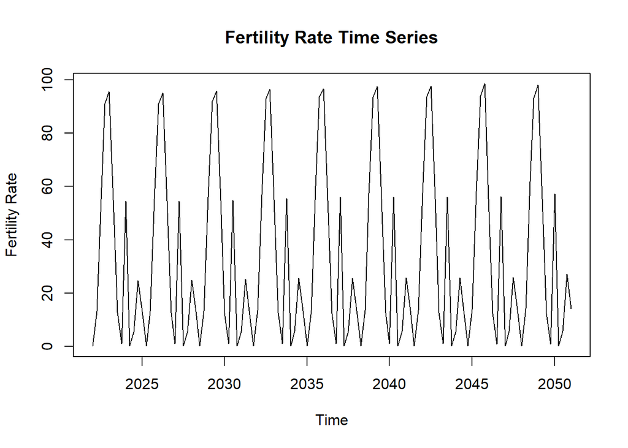

```r
# Filter for 'All races and origins' and set time series
data_filtered <- subset(data, Group == "All races and origins")
fertility_ts <- ts(data_filtered$FertilityRate, start = c(2022, 1), frequency = 4)

# Plot the time series
plot(fertility_ts, main = "Fertility Rate Time Series", ylab = "Fertility Rate", xlab = "Time")
```

```r
# Determine the number of differences needed to make the series stationary
d <- ndiffs(fertility_ts)
cat("Number of differences needed for stationarity: ", d, "\n")
```

```
## Number of differences needed for stationarity:  0
```

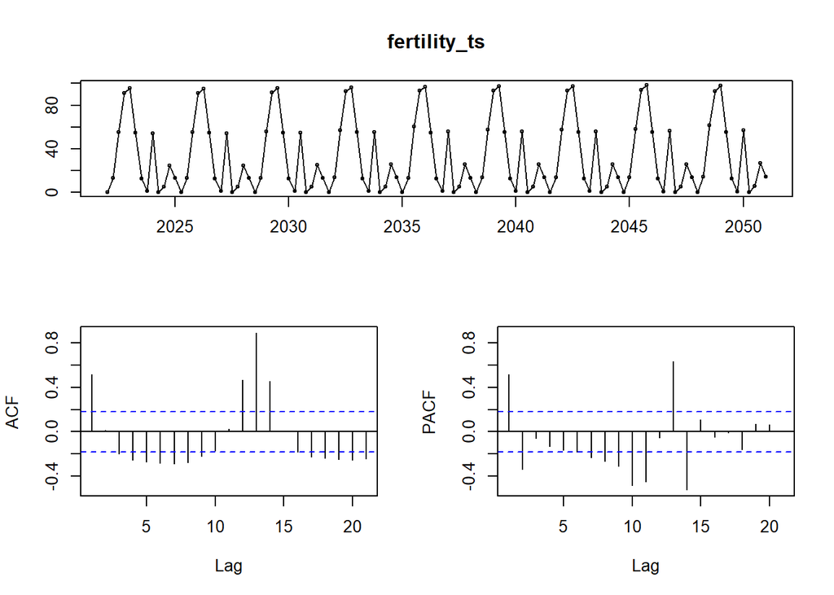

```r
# Display time series characteristics
tsdisplay(fertility_ts)
```

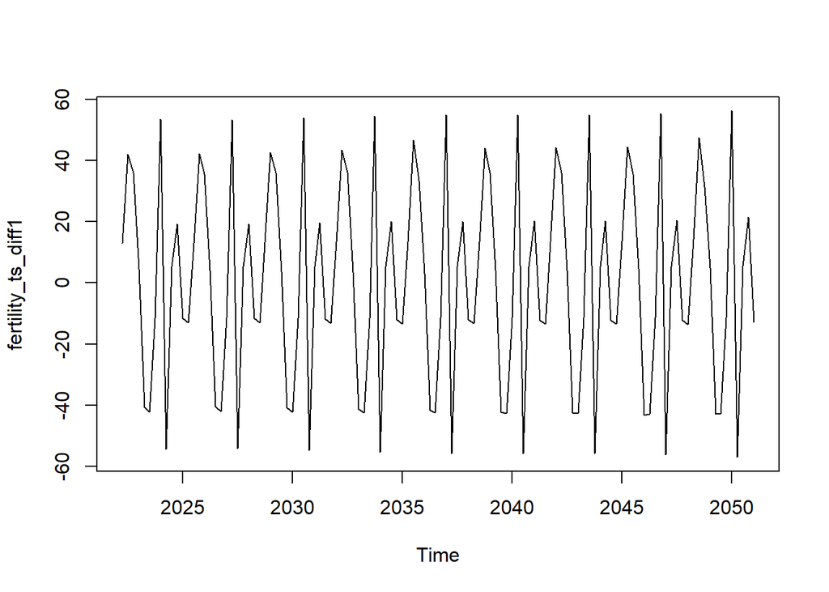

```r
fertility_ts_diff1 <- diff(fertility_ts, differences=1)
plot(fertility_ts_diff1)
```

```r
# Determine the differencing again
ndiffs(fertility_ts_diff1)
```

```
## [1] 0
```

```r
# Fit ARIMA model using auto.arima()
auto_fit <- auto.arima(fertility_ts, trace = TRUE, stepwise = FALSE)
```

```
##
##  ARIMA(0,0,0)           with zero mean     : 1234.738
##  ARIMA(0,0,0)           with non-zero mean : 1156.322
##  ARIMA(0,0,0)(0,0,1)[4] with zero mean     : 1221.85
##  ARIMA(0,0,0)(0,0,1)[4] with non-zero mean : 1145.66
##  ARIMA(0,0,0)(0,0,2)[4] with zero mean     : 1220.651
##  ARIMA(0,0,0)(0,0,2)[4] with non-zero mean : Inf
##  ARIMA(0,0,0)(1,0,0)[4] with zero mean     : 1220.183
##  ARIMA(0,0,0)(1,0,0)[4] with non-zero mean : 1150.518
##  ARIMA(0,0,0)(1,0,1)[4] with zero mean     : Inf
##  ARIMA(0,0,0)(1,0,1)[4] with non-zero mean : Inf
##  ARIMA(0,0,0)(1,0,2)[4] with zero mean     : 1177.16
##  ARIMA(0,0,0)(1,0,2)[4] with non-zero mean : Inf
##  ARIMA(0,0,0)(2,0,0)[4] with zero mean     : 1215.676
##  ARIMA(0,0,0)(2,0,0)[4] with non-zero mean : 1135.841
##  ARIMA(0,0,0)(2,0,1)[4] with zero mean     : Inf
##  ARIMA(0,0,0)(2,0,1)[4] with non-zero mean : 1120.49
##  ARIMA(0,0,0)(2,0,2)[4] with zero mean     : Inf
##  ARIMA(0,0,0)(2,0,2)[4] with non-zero mean : 1122.063
##  ARIMA(0,0,1)           with zero mean     : 1162.388
##  ARIMA(0,0,1)           with non-zero mean : 1114.777
##  ARIMA(0,0,1)(0,0,1)[4] with zero mean     : 1154.479
##  ARIMA(0,0,1)(0,0,1)[4] with non-zero mean : 1114.125
##  ARIMA(0,0,1)(0,0,2)[4] with zero mean     : 1156.275
##  ARIMA(0,0,1)(0,0,2)[4] with non-zero mean : Inf
##  ARIMA(0,0,1)(1,0,0)[4] with zero mean     : 1153.075
##  ARIMA(0,0,1)(1,0,0)[4] with non-zero mean : 1115.277
##  ARIMA(0,0,1)(1,0,1)[4] with zero mean     : Inf
##  ARIMA(0,0,1)(1,0,1)[4] with non-zero mean : Inf
##  ARIMA(0,0,1)(1,0,2)[4] with zero mean     : Inf
##  ARIMA(0,0,1)(1,0,2)[4] with non-zero mean : Inf
##  ARIMA(0,0,1)(2,0,0)[4] with zero mean     : 1154.144
##  ARIMA(0,0,1)(2,0,0)[4] with non-zero mean : 1111.878
##  ARIMA(0,0,1)(2,0,1)[4] with zero mean     : Inf
##  ARIMA(0,0,1)(2,0,1)[4] with non-zero mean : Inf
##  ARIMA(0,0,1)(2,0,2)[4] with zero mean     : Inf
##  ARIMA(0,0,1)(2,0,2)[4] with non-zero mean : Inf
##  ARIMA(0,0,2)           with zero mean     : 1143.996
##  ARIMA(0,0,2)           with non-zero mean : 1112.799
##  ARIMA(0,0,2)(0,0,1)[4] with zero mean     : 1144.626
```

[output cut: 122 more lines]

```
##  ARIMA(3,0,0)(1,0,1)[4] with non-zero mean : Inf
##  ARIMA(3,0,0)(2,0,0)[4] with zero mean     : 1139.819
##  ARIMA(3,0,0)(2,0,0)[4] with non-zero mean : 1071.6
##  ARIMA(3,0,1)           with zero mean     : Inf
##  ARIMA(3,0,1)           with non-zero mean : Inf
##  ARIMA(3,0,1)(0,0,1)[4] with zero mean     : Inf
##  ARIMA(3,0,1)(0,0,1)[4] with non-zero mean : Inf
##  ARIMA(3,0,1)(1,0,0)[4] with zero mean     : Inf
##  ARIMA(3,0,1)(1,0,0)[4] with non-zero mean : Inf
##  ARIMA(3,0,2)           with zero mean     : Inf
##  ARIMA(3,0,2)           with non-zero mean : Inf
##
##
##
##  Best model: ARIMA(3,0,0)(2,0,0)[4] with non-zero mean
```

```r
print(auto_fit)
```

```
## Series: fertility_ts
## ARIMA(3,0,0)(2,0,0)[4] with non-zero mean
##
## Coefficients:
##           ar1      ar2      ar3     sar1     sar2     mean
##       -0.3039  -0.6731  -0.5354  -0.7391  -0.9005  33.2128
## s.e.   0.0875   0.0571   0.0849   0.0430   0.0357   0.3043
##
## sigma^2 = 457.7:  log likelihood = -528.29
## AIC=1070.57   AICc=1071.6   BIC=1089.91
```

```r
# Display attributes of the fitted ARIMA model
attributes(auto_fit)
```

```
## $names
##  [1] "coef"      "sigma2"    "var.coef"  "mask"      "loglik"    "aic"
##  [7] "arma"      "residuals" "call"      "series"    "code"      "n.cond"
## [13] "nobs"      "model"     "bic"       "aicc"      "x"         "fitted"
##
## $class
## [1] "forecast_ARIMA" "ARIMA"          "Arima"
```

1. Explain the output

Data Loading and Filtering: The dataset was loaded, and the time series of fertility rates was filtered for “All races and origins.”

2. Run Residual Analysis

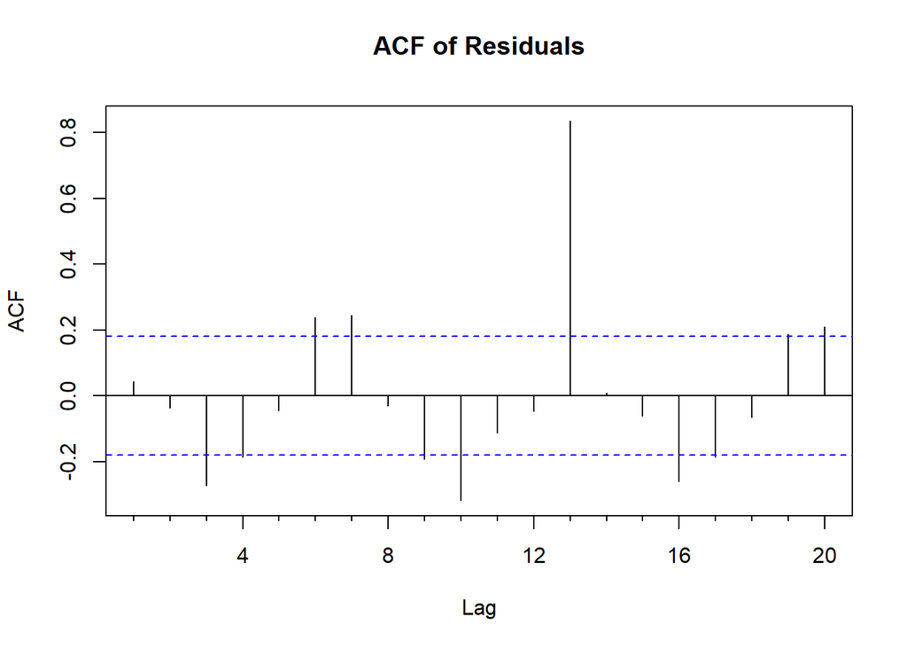

```r
# Residual Analysis
# Plot ACF of residuals
Acf(auto_fit$residuals, main = "ACF of Residuals")
```

```r
# Ljung-Box test to check for independence of residuals
box_test <- Box.test(auto_fit$residuals, lag = 20, type = "Ljung-Box")
print(box_test)
```

```
##
##  Box-Ljung test
##
## data:  auto_fit$residuals
## X-squared = 168.71, df = 20, p-value < 2.2e-16
```

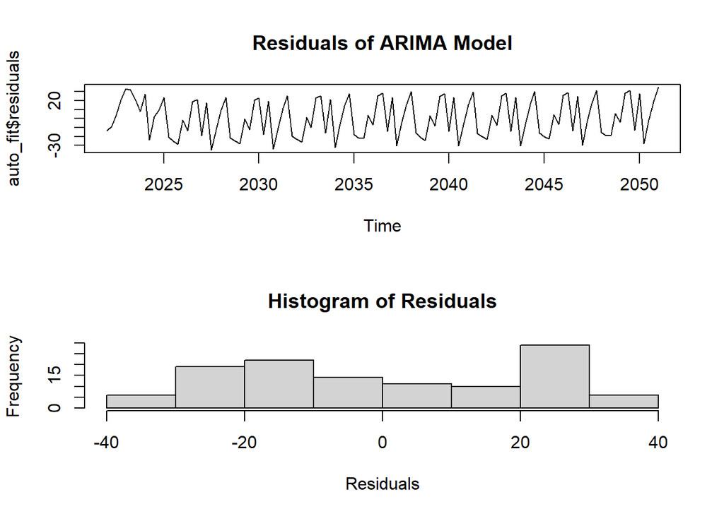

```r
# Plot residuals and histogram
par(mfrow = c(2, 1))
plot.ts(auto_fit$residuals, main = "Residuals of ARIMA Model")
hist(auto_fit$residuals, main = "Histogram of Residuals", xlab = "Residuals")
```

```r
par(mfrow = c(1, 1))
```

3. Perform and Plot the forecast for the next five periods

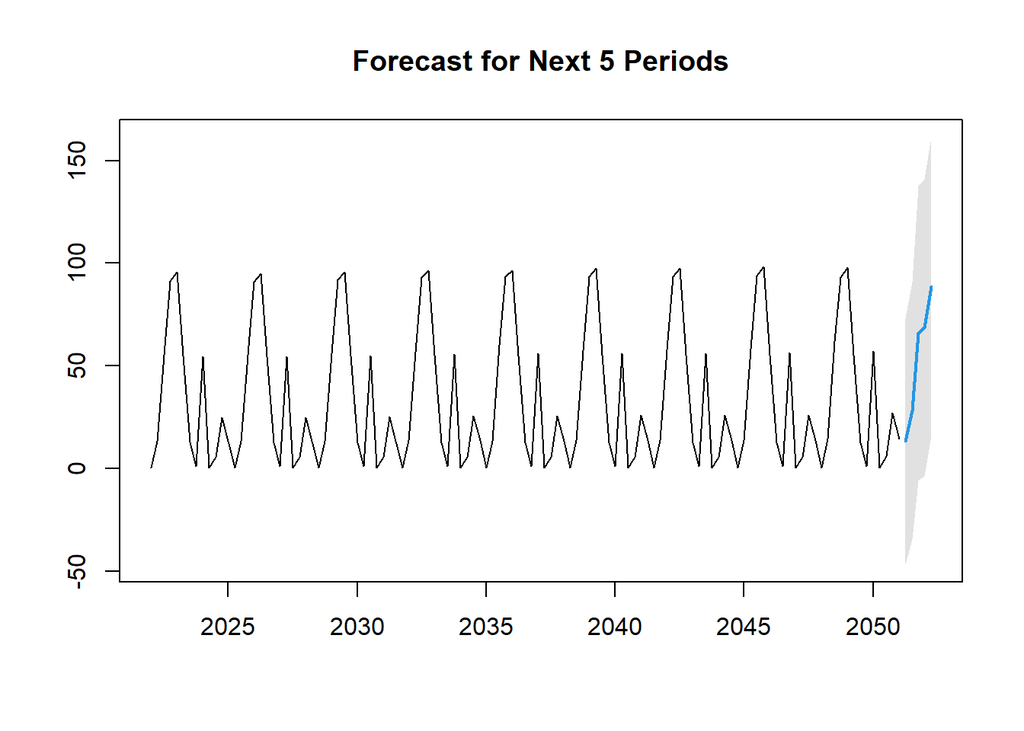

```r
# Forecast for the next 5 periods and plot the forecast
plot(forecast(auto_fit, h = 5, level = c(99.5)), main = "Forecast for Next 5 Periods")
```

Forecast: Predicted the fertility rate for the next 5 periods. The forecast plot included a blue line for the predicted values, and a shaded area showed the range in which future values are likely to fall, with a high confidence level of 99.5%.

4. Show the accuracy of your ARIMA model

```r
# Show the accuracy of the ARIMA model
accuracy_metrics <- accuracy(auto_fit)
print(accuracy_metrics)
```

```
##                     ME     RMSE      MAE       MPE     MAPE     MASE       ACF1
## Training set 0.6790997 20.83775 18.80232 -1910.738 2010.636 0.428299 0.04320273
```